# Part 2 - The Impact of Employment Status, Average Credit Score, and Recommendations on Loan Approval

## Investigation Overview

In this investigation, i want to look at which of the features of a loan could be use to predict its' complete or default status. The main focus will be on employment status, average credit score and recommendations count.

## Dataset Overview

The dataset comprises 113,937 records of Prosper loan data, encompassing loan status along with various attributes such as borrower rate (interest rate), employment status, recommendations count, borrower income, and more.

To create a subset, only loan status values categorized as "Completed," "Defaulted," or "ChargedOff" were included, as well as credit score ranges greater than or equal to 400.

## Loan Status Distribution

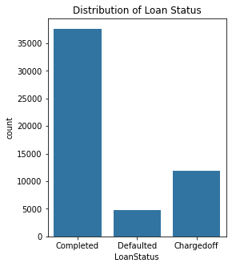

Loan status is represented as a categorical variable, and the count plot illustrates that the dataset contains a higher number of completed loans compared to the number of defaults.

## Distribution of Employment Status

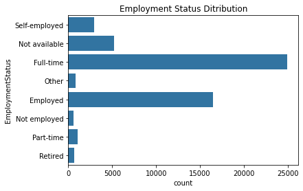

The dataset exhibits a higher representation of employed individuals compared to unemployed individuals based on their respective employment statuses.

## Distribution of Average Credit Score

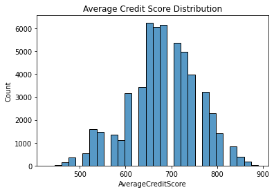

The average credit score distribution demonstrates a slight normal pattern, with the majority of values concentrated within the range of 600 to 800.

## Recommendation count distribution

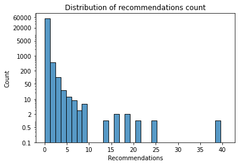

Distribution highlights a majority of counts below 10, with only a few values surpassing this Threshold.

## Loan Status vs Employment Status

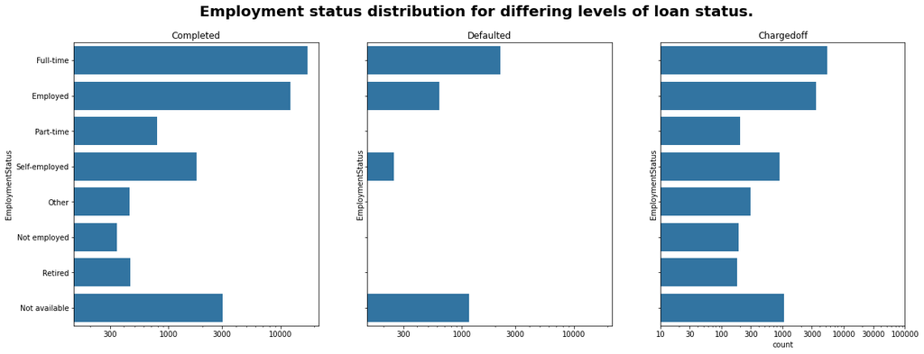

These findings imply that fully employed individuals are less likely to default on their loans compared to those who are not fully employed.

### Loan Status and employment status by average credit score

[figure not shown]

Loan completion rates are higher among fully employed individuals. However, fully employed borrowers who default on their loans exhibit lower average credit scores compared to those who successfully repay their loans. Notably, the highest likelihood of loan default is observed among individuals who select "Not available" as their employment status, with a majority of them also having average credit scores below 650.

### Loan Status and employment status by recommendations count

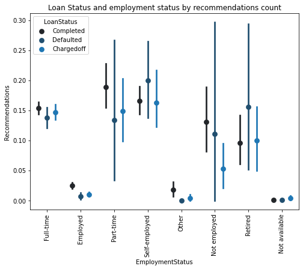